# Okesola Moses_Hacthatons2A_project

2.All the distributions have outliers at the right hand side with some them to the extreme.

**Univariate analysis of categorical variables in train set**

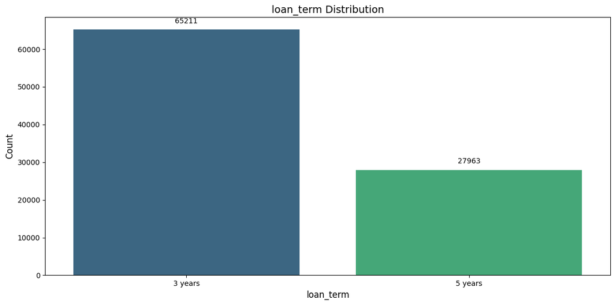

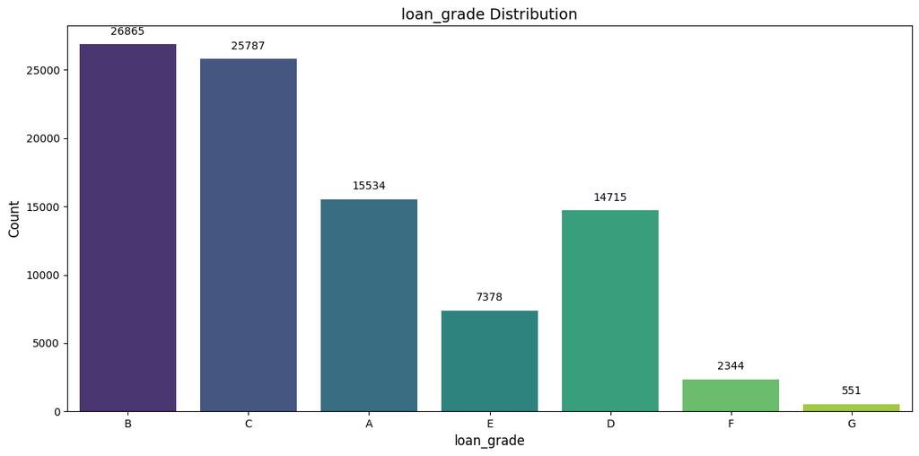

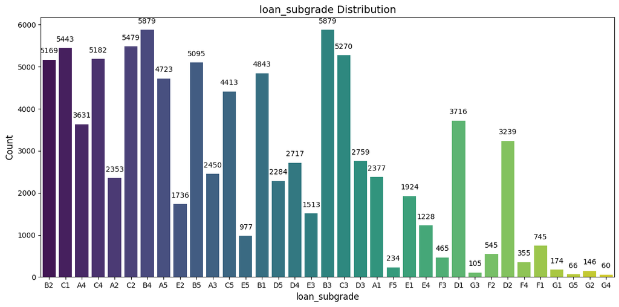

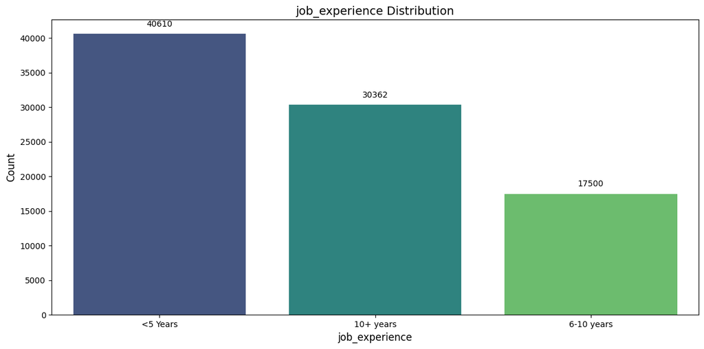

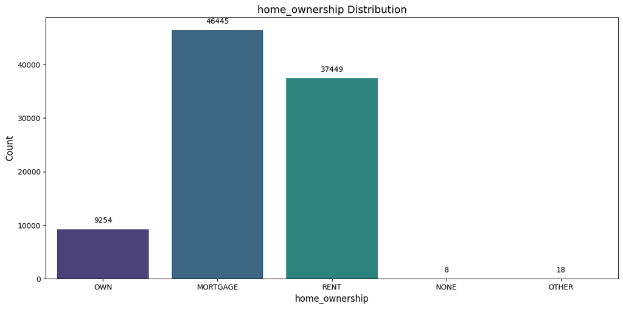

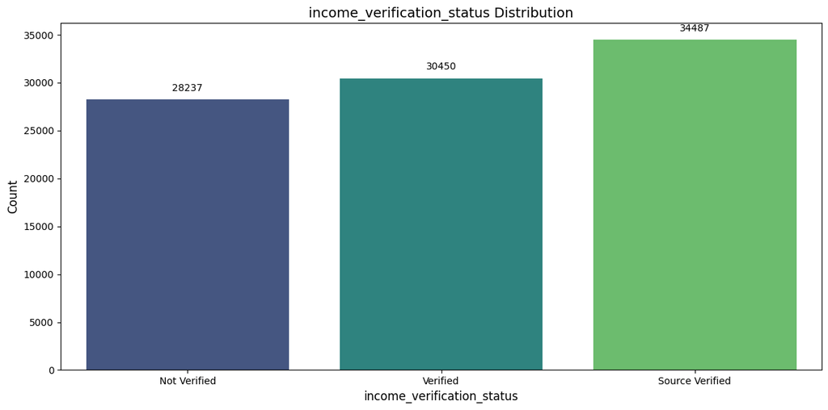

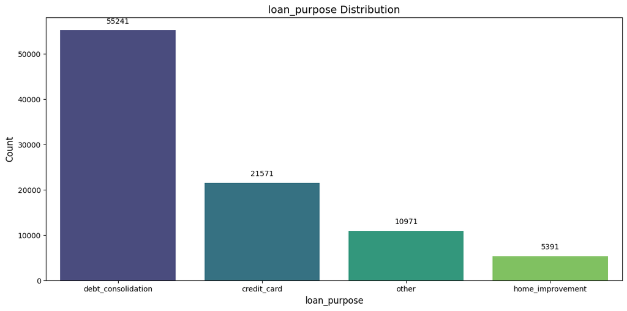

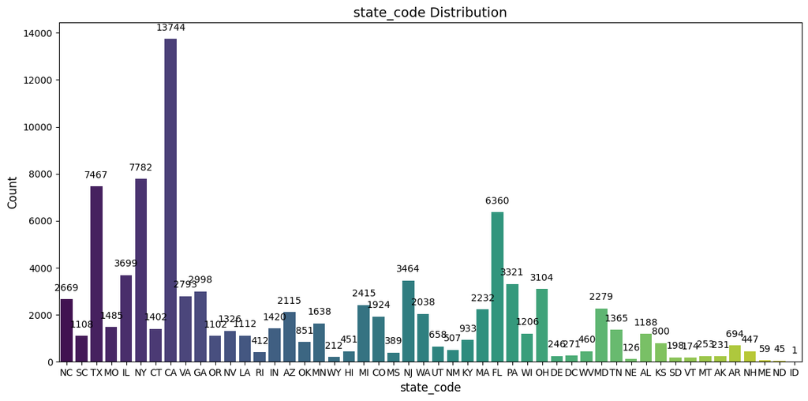

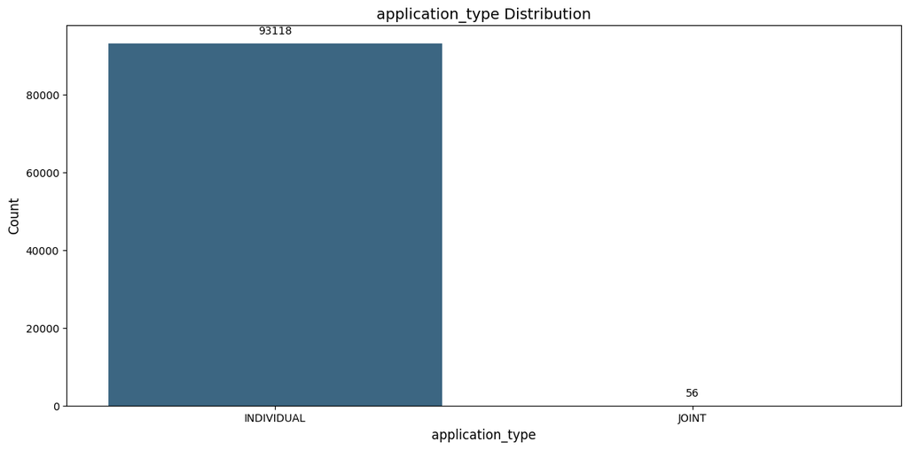

```python
# Iterate and plot labeled bar plots for each categorical column
for var in categorical_cols:
    labelled_barplot(df, var, title=f'{var} Distribution')
```

**Univariate analysis of categorical variables in test set**

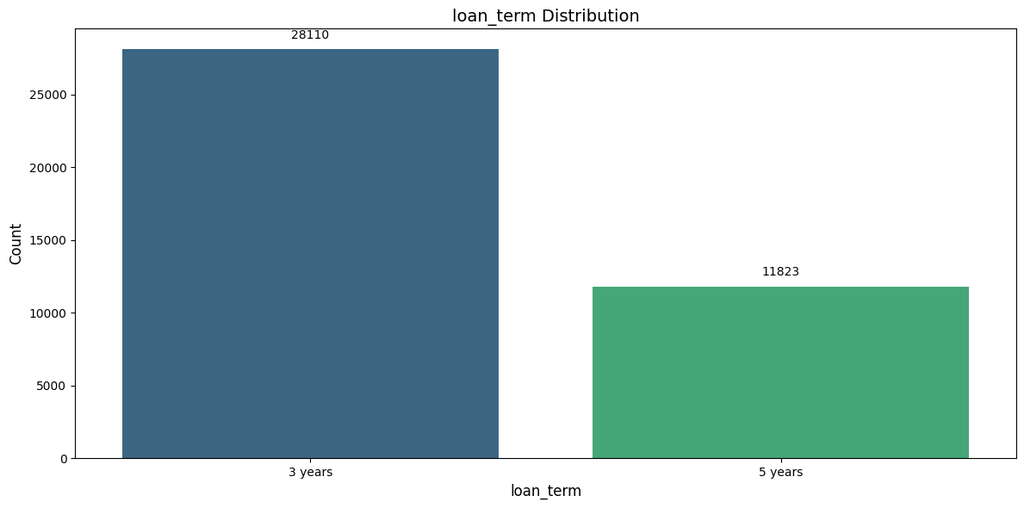

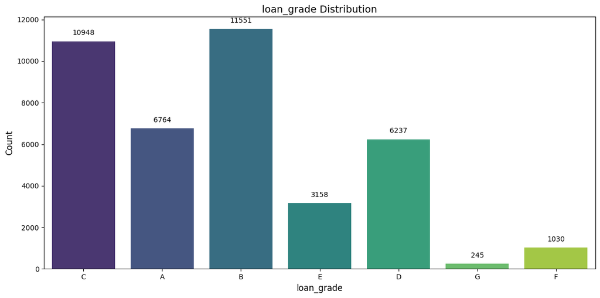

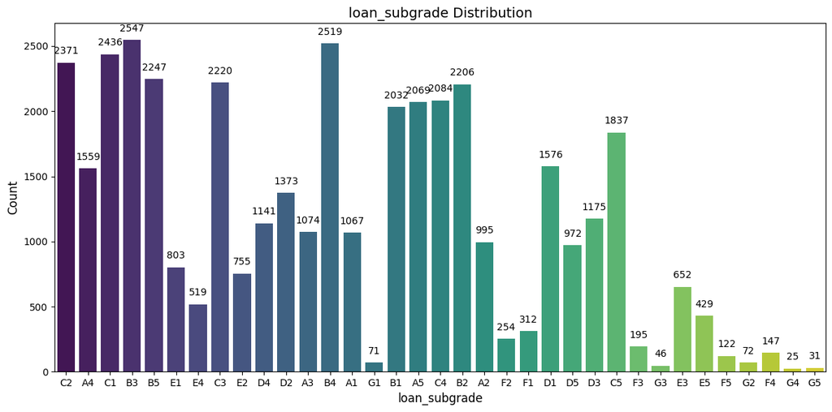

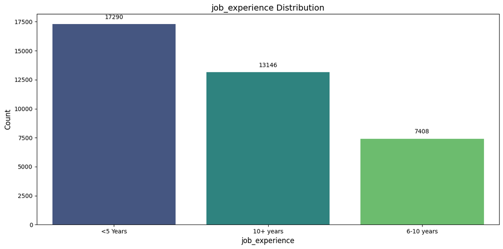

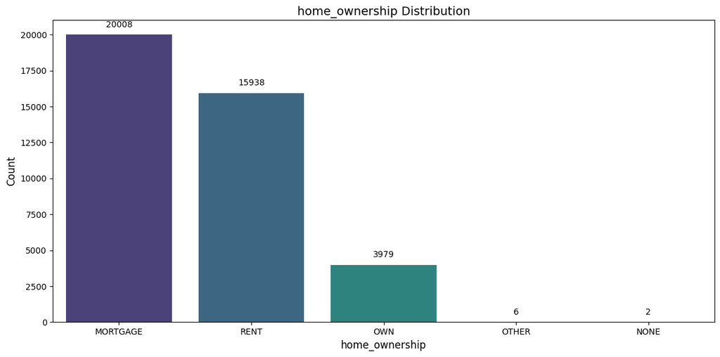

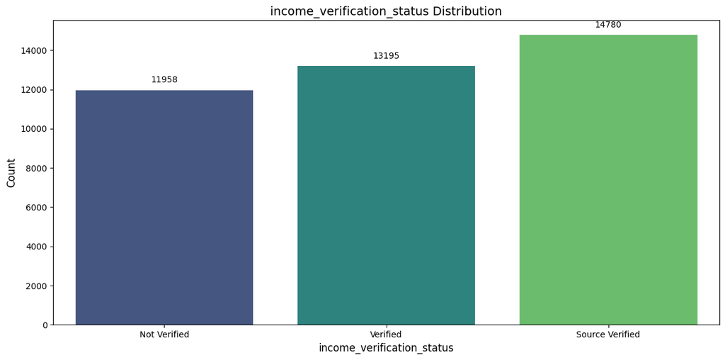

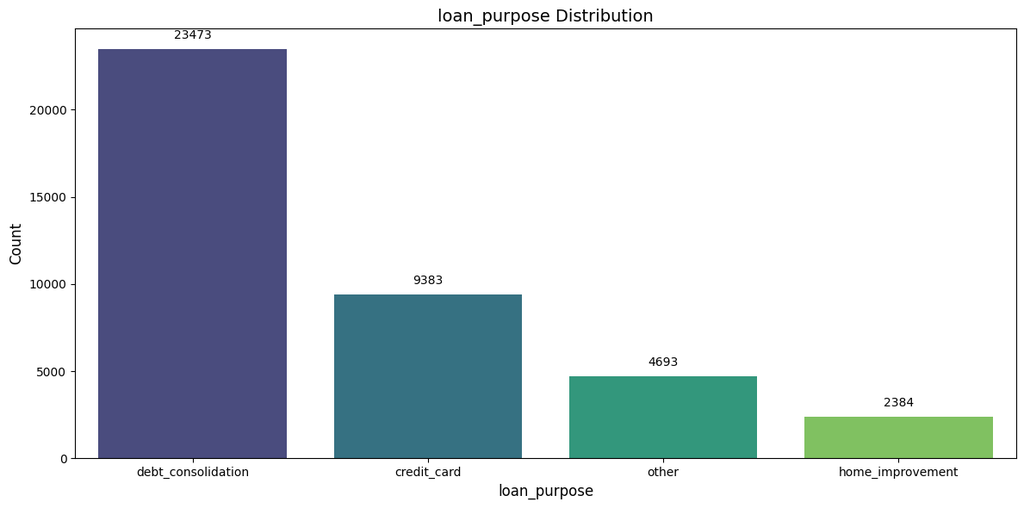

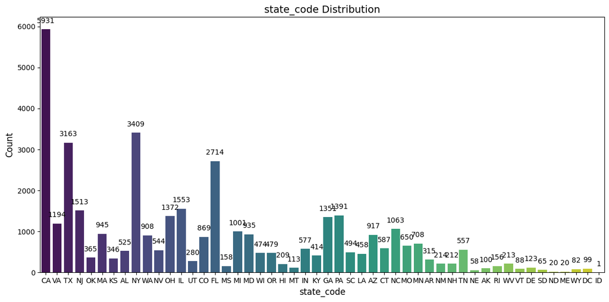

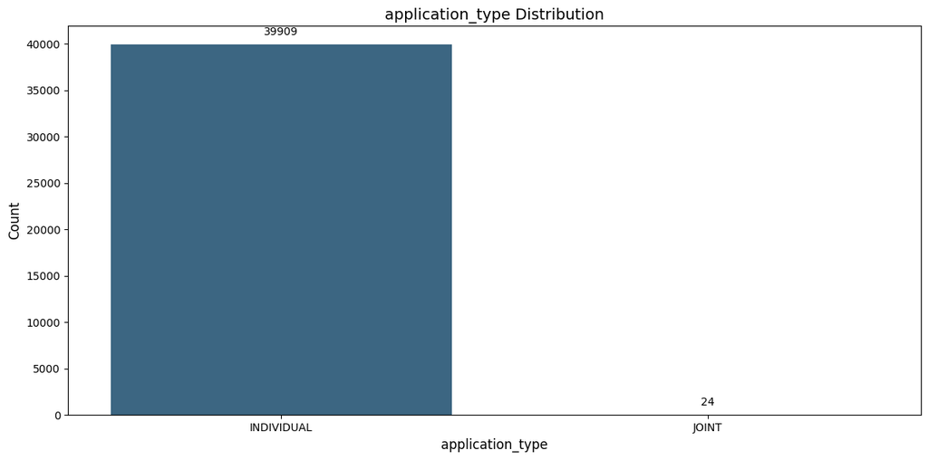

```python
# Iterate and plot labeled bar plots for each categorical variable
for var in categorical_cols:
    labelled_barplot(df1, var, title=f'{var} Distribution')
```

**Bivariate Analysis**

**correlation check among Train dataset variables**

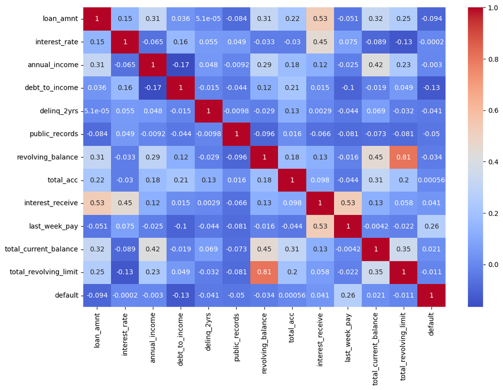

```python
# Check correlation matrix
plt.figure(figsize=(12,8))
sns.heatmap(df.corr(), annot=True, cmap='coolwarm')
plt.show()
```

**correlation check among Test dataset variables**

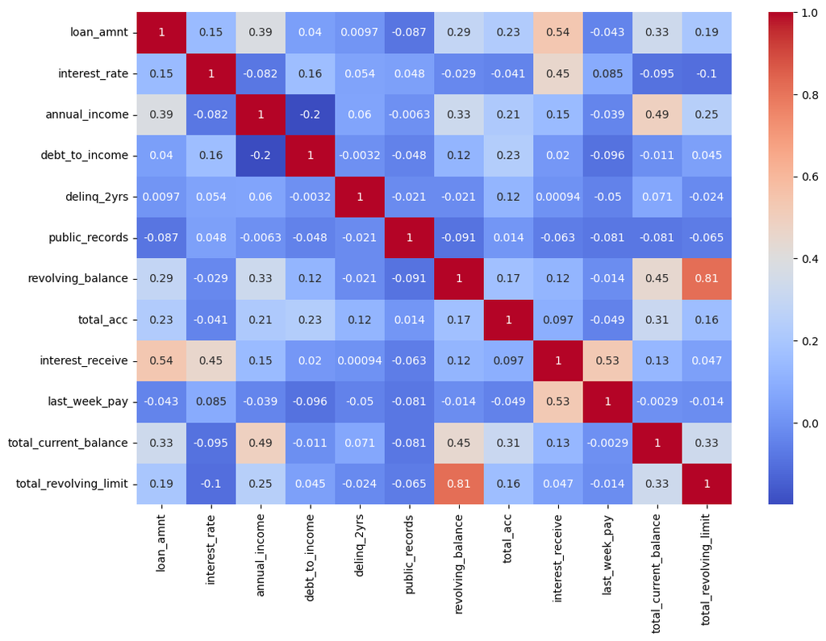

```python
# Check correlation matrix
plt.figure(figsize=(12,8))
sns.heatmap(df1.corr(), annot=True, cmap='coolwarm')
plt.show()
```

1.There is a moderate positive correlation between loan amount and interest received. 2.There is a moderate positive correlation between last week pay and interest received. 3.There is a strong positive correlation between revolving balance and total revolving limit.

```python
def stacked_barplot(data, predictor, target):
    """
    Print the category counts and plot a stacked bar chart

    data: dataframe
    predictor: independent variable
    target: target variable
    """
    count = data[predictor].nunique()
    sorter = data[target].value_counts().index[-1]
    tab1 = pd.crosstab(data[predictor], data[target], margins=True).sort_values(
        by=sorter, ascending=False
    )
    print(tab1)
    print("-" * 120)
    tab = pd.crosstab(data[predictor], data[target], normalize="index").sort_values(
        by=sorter, ascending=False
    )
    tab.plot(kind="bar", stacked=True, figsize=(count + 5, 5))
    plt.legend(
        loc="lower left", frameon=False,
    )
    plt.legend(loc="upper left", bbox_to_anchor=(1, 1))
    plt.show()
```

```
default        0      1    All
loan_term
All        71045  22129  93174
3 years    47345  17866  65211
5 years    23700   4263  27963
------------------------------------------------------------------------------------------------------------------------
```

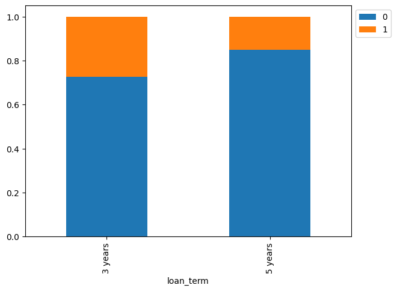

```
default         0      1    All
loan_grade
All         71045  22129  93174
B           19787   7078  26865
C           20203   5584  25787
A           11281   4253  15534
D           11478   3237  14715
E            6003   1375   7378
F            1862    482   2344
G             431    120    551
------------------------------------------------------------------------------------------------------------------------
```

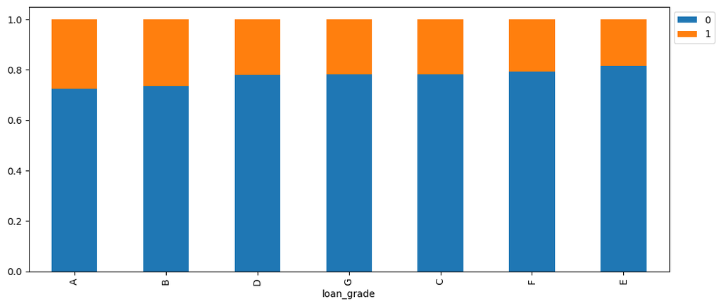

```
default            0      1    All
loan_subgrade
All            71045  22129  93174
B3              4196   1683   5879
B4              4335   1544   5879
B2              3750   1419   5169
C1              4152   1291   5443
B5              3837   1258   5095
C2              4264   1215   5479
B1              3669   1174   4843
A5              3558   1165   4723
A4              2502   1129   3631
C3              4150   1120   5270
C4              4161   1021   5182
C5              3476    937   4413
D1              2932    784   3716
D2              2462    777   3239
A3              1731    719   2450
D3              2114    645   2759
A2              1710    643   2353
A1              1780    597   2377
D4              2154    563   2717
D5              1816    468   2284
E1              1598    326   1924
E3              1206    307   1513
E2              1436    300   1736
E4               996    232   1228
E5               767    210    977
F1               590    155    745
F2               437    108    545
F3               363    102    465
F4               280     75    355
F5               192     42    234
G1               133     41    174
G2               118     28    146
G3                82     23    105
G4                46     14     60
G5                52     14     66
------------------------------------------------------------------------------------------------------------------------
```

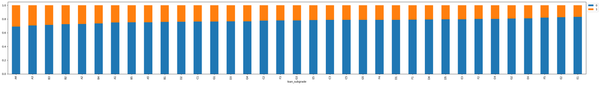

```
default             0      1    All
job_experience
All             67140  21332  88472
<5 Years        30377  10233  40610
10+ years       23656   6706  30362
6-10 years      13107   4393  17500
------------------------------------------------------------------------------------------------------------------------
```

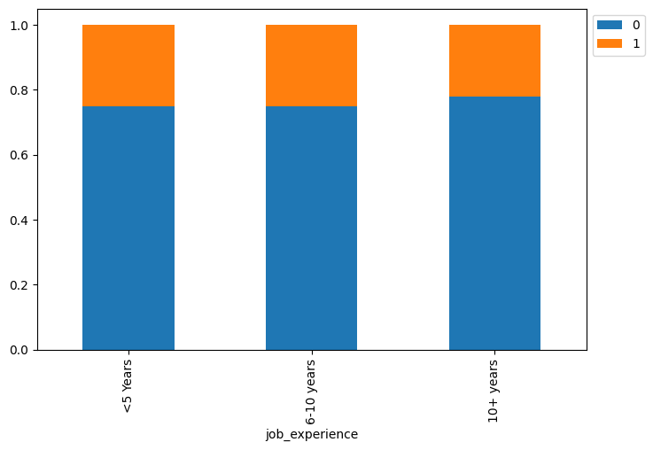

```
default             0      1    All
home_ownership
All             71045  22129  93174
MORTGAGE        35316  11129  46445
RENT            28401   9048  37449
OWN              7323   1931   9254
OTHER               3     15     18
NONE                2      6      8
------------------------------------------------------------------------------------------------------------------------
```

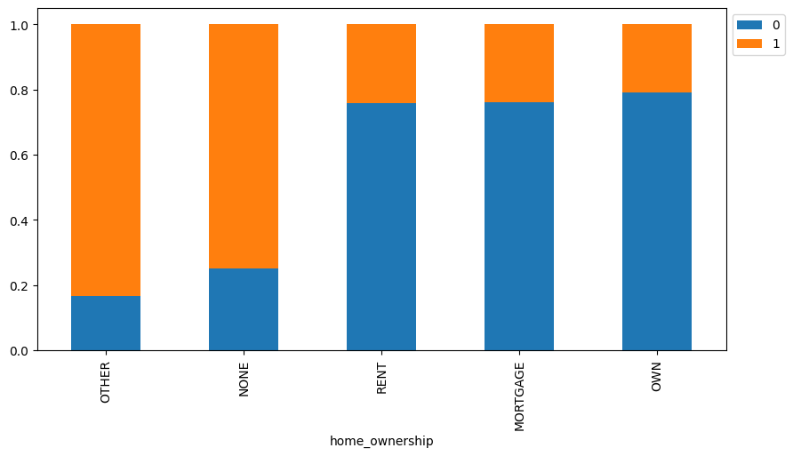

```
default                         0      1    All
income_verification_status
All                         71045  22129  93174
Not Verified                20329   7908  28237
Verified                    22654   7796  30450
Source Verified             28062   6425  34487
------------------------------------------------------------------------------------------------------------------------
```

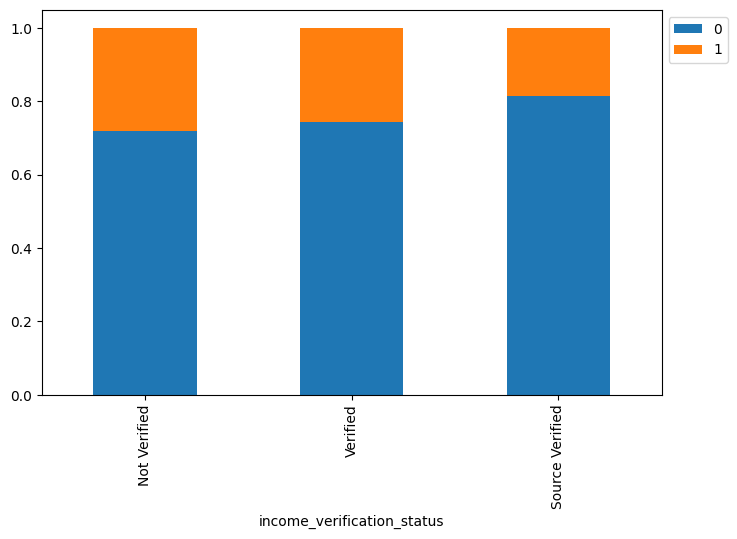

```
default                 0      1    All
loan_purpose
All                 71045  22129  93174
debt_consolidation  42408  12833  55241
credit_card         17006   4565  21571
other                7563   3408  10971
home_improvement     4068   1323   5391
------------------------------------------------------------------------------------------------------------------------
```

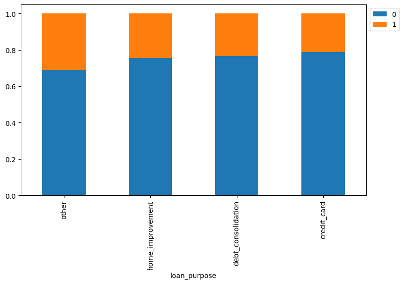

```
default         0      1    All
state_code
All         71045  22129  93174
CA           9905   3839  13744
NY           5886   1896   7782
TX           5748   1719   7467
FL           4876   1484   6360
IL           2864    835   3699
NJ           2640    824   3464
PA           2616    705   3321
GA           2324    674   2998
VA           2141    652   2793
OH           2467    637   3104
NC           2050    619   2669
MA           1648    584   2232
MD           1704    575   2279
AZ           1583    532   2115
WA           1517    521   2038
MI           1911    504   2415
CO           1431    493   1924
MN           1254    384   1638
NV            983    343   1326
MO           1144    341   1485
CT           1083    319   1402
OR            805    297   1102
AL            915    273   1188
WI            940    266   1206
SC            847    261   1108
LA            854    258   1112
IN           1188    232   1420
KY            731    202    933
TN           1168    197   1365
UT            465    193    658
OK            664    187    851
KS            638    162    800
AR            536    158    694
HI            327    124    451
NH            337    110    447
NM            403    104    507
RI            313     99    412
WV            368     92    460
DC            183     88    271
AK            170     61    231
MT            198     55    253
DE            195     51    246
WY            163     49    212
SD            150     48    198
VT            129     45    174
MS            357     32    389
NE            124      2    126
ME             57      2     59
ID              0      1      1
ND             45      0     45
------------------------------------------------------------------------------------------------------------------------
```

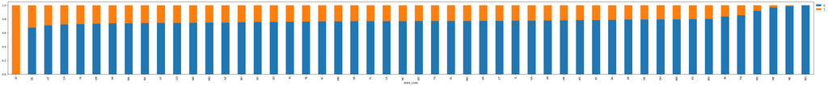

```
default               0      1    All
application_type
INDIVIDUAL        70989  22129  93118
All               71045  22129  93174
JOINT                56      0     56
------------------------------------------------------------------------------------------------------------------------
```

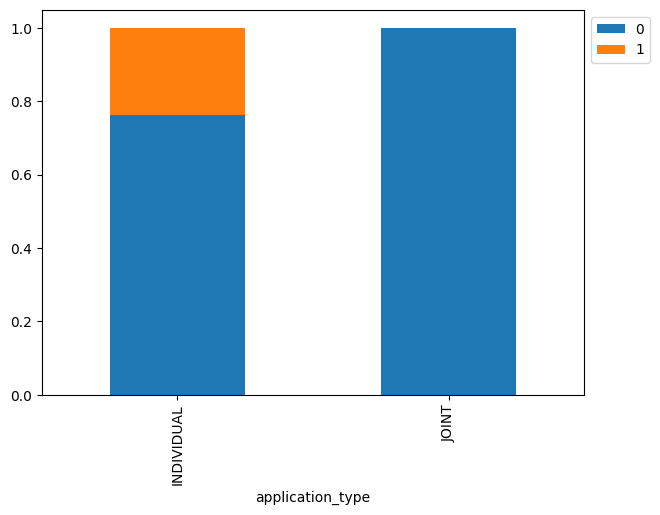

```python
for var in categorical_cols:
    stacked_barplot(train_data, var, "default")
```

1. There are more loan default with 3 years loan-term than 5 years loan term. 2. There are more loan default with 'A' loan_grade than others. 3. There are more loan default with 'A4' loan_subgrade than others. 4. There are more loan default with '< 5 years' job_experience category than others. 5. There are more loan default with 'OTHER' home_ownership status than others. 6. There are more loan default with 'Not verified' income_verification_status than others. 7. There are more loan default with 'other' loan_purpose than others. 8. There are 100% loan default with state_code ID loan_purpose but CA has the highest number of loan defaulters. 9. 'Individual' application_type has the highest loan defaulters while 'joint' application_type has 0% loan defaulters.

**Further Analysis based on correlation check of independent variables that are positively correlated to dependent variable: 'default'**

```python
## Function to plot distributions


def distribution_plot_wrt_target(data, predictor, target):

    fig, axs = plt.subplots(2, 2, figsize=(12, 10))

    target_uniq = data[target].unique()

    axs[0, 0].set_title("Distribution of target for target=" + str(target_uniq[0]))
    sns.histplot(
        data=data[data[target] == target_uniq[0]],
        x=predictor,
        kde=True,
        ax=axs[0, 0],
        color="teal",
    )

    axs[0, 1].set_title("Distribution of target for target=" + str(target_uniq[1]))
    sns.histplot(
        data=data[data[target] == target_uniq[1]],
        x=predictor,
        kde=True,
        ax=axs[0, 1],
        color="orange",
    )

    axs[1, 0].set_title("Boxplot w.r.t target")
    sns.boxplot(data=data, x=target, y=predictor, ax=axs[1, 0], palette="gist_rainbow")

    axs[1, 1].set_title("Boxplot (without outliers) w.r.t target")
    sns.boxplot(
        data=data,
        x=target,
        y=predictor,
        ax=axs[1, 1],
        showfliers=False,
        palette="gist_rainbow",
    )

    plt.tight_layout()
    plt.show()
```

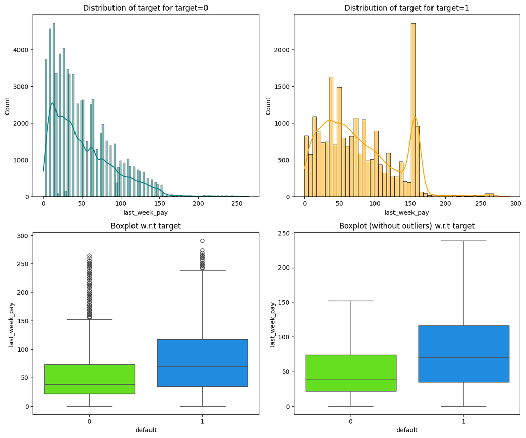

```python
 distribution_plot_wrt_target(df, "last_week_pay", "default")
```

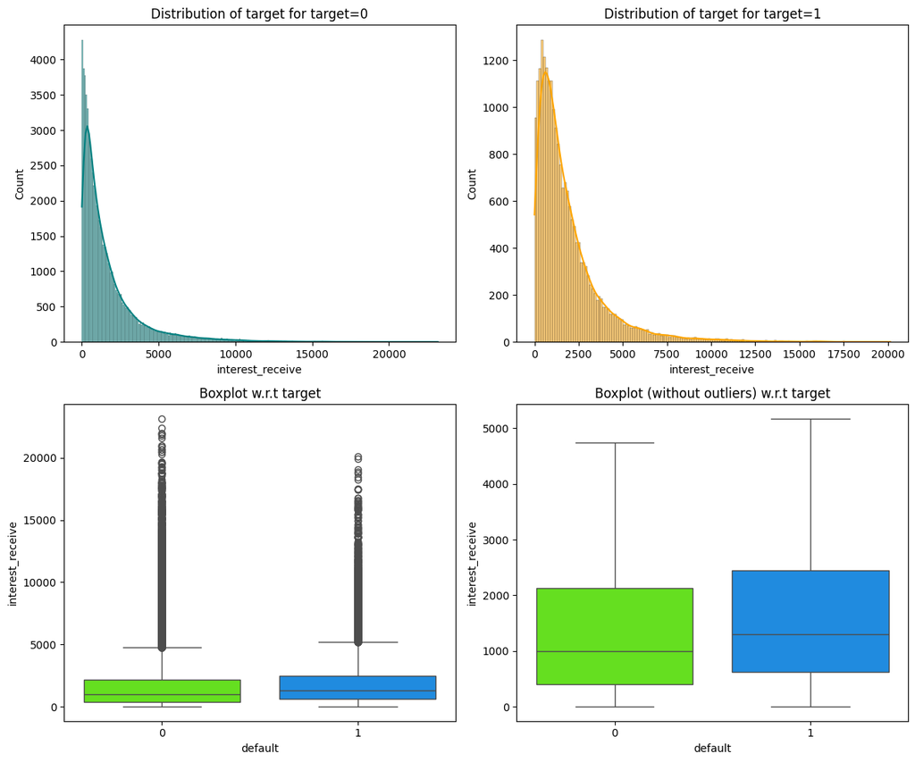

```python
distribution_plot_wrt_target(df, "interest_receive", "default")
```

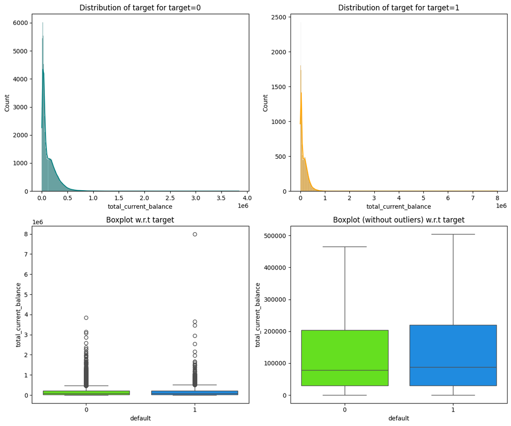

```python
distribution_plot_wrt_target(df, "total_current_balance", "default")
```

**Data Preprocessing**

**Fill the missing values**

```python
df.fillna(df.mean(), inplace=True)
df1.fillna(df1.mean(), inplace=True)
```

```python
df.info()
```

```
<class 'pandas.core.frame.DataFrame'>
RangeIndex: 93174 entries, 0 to 93173
Data columns (total 22 columns):
 #   Column                      Non-Null Count  Dtype
---  ------                      --------------  -----
 0   loan_amnt                   93174 non-null  int64
 1   loan_term                   93174 non-null  object
 2   interest_rate               93174 non-null  float64
 3   loan_grade                  93174 non-null  object
 4   loan_subgrade               93174 non-null  object
 5   job_experience              88472 non-null  object
 6   home_ownership              93174 non-null  object
 7   annual_income               93174 non-null  float64
 8   income_verification_status  93174 non-null  object
 9   loan_purpose                93174 non-null  object
 10  state_code                  93174 non-null  object
 11  debt_to_income              93174 non-null  float64
 12  delinq_2yrs                 93174 non-null  float64
 13  public_records              93174 non-null  float64
 14  revolving_balance           93174 non-null  int64
 15  total_acc                   93174 non-null  float64
 16  interest_receive            93174 non-null  float64
 17  application_type            93174 non-null  object
 18  last_week_pay               93174 non-null  float64
 19  total_current_balance       93174 non-null  float64
 20  total_revolving_limit       93174 non-null  float64
 21  default                     93174 non-null  int64
dtypes: float64(10), int64(3), object(9)
memory usage: 15.6+ MB
```

```python
df1.info()
```

```
<class 'pandas.core.frame.DataFrame'>
RangeIndex: 39933 entries, 0 to 39932
Data columns (total 21 columns):
 #   Column                      Non-Null Count  Dtype
---  ------                      --------------  -----
 0   loan_amnt                   39933 non-null  int64
 1   loan_term                   39933 non-null  object
 2   interest_rate               39933 non-null  float64
 3   loan_grade                  39933 non-null  object
 4   loan_subgrade               39933 non-null  object
 5   job_experience              37844 non-null  object
 6   home_ownership              39933 non-null  object
 7   annual_income               39933 non-null  float64
 8   income_verification_status  39933 non-null  object
 9   loan_purpose                39933 non-null  object
 10  state_code                  39933 non-null  object
 11  debt_to_income              39933 non-null  float64
 12  delinq_2yrs                 39933 non-null  float64
 13  public_records              39933 non-null  float64
 14  revolving_balance           39933 non-null  int64
 15  total_acc                   39933 non-null  float64
 16  interest_receive            39933 non-null  float64
 17  application_type            39933 non-null  object
 18  last_week_pay               39933 non-null  float64
 19  total_current_balance       39933 non-null  float64
 20  total_revolving_limit       39933 non-null  float64
dtypes: float64(10), int64(2), object(9)
memory usage: 6.4+ MB
```

**We shall fill the missing values in 'job_experience' column using mode**

```python
# fill with the most frequent value
most_frequent_value = df1['job_experience'].mode()[0]
df1['job_experience'] = df1['job_experience'].fillna(most_frequent_value)
```

```python
df1.info()
```

```
<class 'pandas.core.frame.DataFrame'>
RangeIndex: 39933 entries, 0 to 39932
Data columns (total 21 columns):
 #   Column                      Non-Null Count  Dtype
---  ------                      --------------  -----
 0   loan_amnt                   39933 non-null  int64
 1   loan_term                   39933 non-null  object
 2   interest_rate               39933 non-null  float64
 3   loan_grade                  39933 non-null  object
 4   loan_subgrade               39933 non-null  object
 5   job_experience              39933 non-null  object
 6   home_ownership              39933 non-null  object
 7   annual_income               39933 non-null  float64
 8   income_verification_status  39933 non-null  object
 9   loan_purpose                39933 non-null  object
 10  state_code                  39933 non-null  object
 11  debt_to_income              39933 non-null  float64
 12  delinq_2yrs                 39933 non-null  float64
 13  public_records              39933 non-null  float64
 14  revolving_balance           39933 non-null  int64
 15  total_acc                   39933 non-null  float64
 16  interest_receive            39933 non-null  float64
 17  application_type            39933 non-null  object
 18  last_week_pay               39933 non-null  float64
 19  total_current_balance       39933 non-null  float64
 20  total_revolving_limit       39933 non-null  float64
dtypes: float64(10), int64(2), object(9)
memory usage: 6.4+ MB
```

There are no more missing values in test data.

```python
for col in categorical_cols:
    print(f"{col}:")
    print(f"  Count of non-null values: {df[var].count()}")
    print(f"  Unique values: {', '.join(map(str, df[var].unique()))}\n")
```

```
loan_term:
  Count of non-null values: 93174
  Unique values: INDIVIDUAL, JOINT

loan_grade:
  Count of non-null values: 93174
  Unique values: INDIVIDUAL, JOINT

loan_subgrade:
  Count of non-null values: 93174
  Unique values: INDIVIDUAL, JOINT

job_experience:
  Count of non-null values: 93174
  Unique values: INDIVIDUAL, JOINT

home_ownership:
  Count of non-null values: 93174
  Unique values: INDIVIDUAL, JOINT

income_verification_status:
  Count of non-null values: 93174
  Unique values: INDIVIDUAL, JOINT

loan_purpose:
  Count of non-null values: 93174
  Unique values: INDIVIDUAL, JOINT

state_code:
  Count of non-null values: 93174
  Unique values: INDIVIDUAL, JOINT

application_type:
  Count of non-null values: 93174
  Unique values: INDIVIDUAL, JOINT
```

**Features and target definition**

```python
# Features and Target Definition
X = df.drop(columns=['default'])
y = df['default']
X_test=df1
```

```python
# Replace special characters in column names for both df and df1
X.columns = X.columns.str.replace(r'[[]|[]]|<', '', regex=True)
df1.columns = df1.columns.str.replace(r'[()\[\]<>]', '', regex=True)
```

```python
# Identify categorical columns
categorical_cols = X.select_dtypes(include=['object']).columns.tolist()
```

**Encoding Categorical variables**

```python
# Apply LabelEncoder to categorical columns
le = LabelEncoder()
for col in categorical_cols:
    X[col] = le.fit_transform(X[col])
    if col in df1.columns:
        df1[col] = df1[col].map(lambda s: '<Unknown>' if s not in le.classes_ else s)
        le.classes_ = np.append(le.classes_, '<Unknown>')
        df1[col] = le.transform(df1[col])
```

```python
X_test = df1
```

```python
# Ensure columns in X_test match those in X
X_test = df1.reindex(columns=X.columns, fill_value=0)
```

```python
# Combine into one DataFrame for preprocessing (to ensure same encoding/scaling)
combined = pd.concat([X, X_test], axis=0)
```

**Scale numerical columns**

```python
# Identify numerical columns
numerical_cols = X.select_dtypes(include=np.number).columns.tolist()

# Scale numerical columns
scaler = StandardScaler()
combined[numerical_cols] = scaler.fit_transform(combined[numerical_cols])
```

```python
# Separate them back after preprocessing
X = combined.iloc[:len(X), :]
X_test = combined.iloc[len(X):, :]
```

**Split the data for validation**

```python
# Split the data for validation
X_train, X_val, y_train, y_val = train_test_split(X, y, test_size=0.2, random_state=42)
```

```python
X_train.shape
```

```
(74539, 21)
```

```python
X_val.shape
```

```
(18635, 21)
```

```python
X_test.shape
```

```
(39933, 21)
```

**Model Building**

**Model evaluation criterion** The nature of predictions made by the classification model will translate as follows: 1.True positives (TP) are defaults correctly predicted by the model. 2.False negatives (FN) are real loan defaults where there is no detection by model. 3.False positives (FP) are loan defaults detections where there is no default. ##Which metric to measure? 1.Our score is the percentage of all correct predictions made. This is simply known as accuracy. 2.The best accuracy is 1 whereas the worst is 0. 3.It will be calculated as the total number of two correct predictions (True positive + True negative) divided by the total number of observations in the dataset.

**Define models to test on orginal data**

```python
models = {
    'Decision Tree': DecisionTreeClassifier(random_state=1),
    'Logistic Regression': LogisticRegression(max_iter=1000, random_state=42),
    'Random Forest': RandomForestClassifier(n_estimators=100, random_state=42),
    'Gradient Boosting': GradientBoostingClassifier(n_estimators=100, random_state=42),
    'XG Boosting': XGBClassifier(n_estimators=100, random_state=42),
    'Ada Boost': AdaBoostClassifier(n_estimators=100, random_state=42),
    'K-Nearest Neighbors': KNeighborsClassifier()
}
```

**Evaluate each model**

```python
for name, model in models.items():
    model.fit(X_train, y_train)
    y_pred = model.predict(X_val)
    accuracy =  accuracy_score(y_val, y_pred)
    print(f'{name} Validation Accuracy: {accuracy * 100:.2f}%')
```

```
Decision Tree Validation Accuracy: 79.96%
Logistic Regression Validation Accuracy: 76.74%
Random Forest Validation Accuracy: 82.80%
Gradient Boosting Validation Accuracy: 82.42%
XG Boosting Validation Accuracy: 87.15%
Ada Boost Validation Accuracy: 81.84%
K-Nearest Neighbors Validation Accuracy: 76.56%
```

XG Boosting has the highest Validation Accuracy follow by Random Forest. We shall try to tune the most performing model(XGBoost) for better prediction.

**Models hyperparameter tuning using GridSearchCV and RandomizedSearchCV**

**XGB GridSearchCV**

```python
%%time
# Define the XGBoost model
model = XGBClassifier(random_state=42, eval_metric='logloss')

# Parameter grid to pass in GridSearchCV
param_grid = {
    'scale_pos_weight': [5, 10],
    'gamma': [0, 3, 5],
    'subsample': [0.8, 0.9],
    'n_estimators': [150,200,250],
    'learning_rate': [0.1, 0.2],
}

# Type of scoring used to compare parameter combinations
scorer = make_scorer(accuracy_score)

# Calling GridSearchCV
grid_cv = GridSearchCV(estimator=model, param_grid=param_grid, scoring=scorer, cv=5, n_jobs=-1)

# Fitting parameters in GridSearchCV
grid_cv.fit(X_train, y_train)

print("Best Parameters: {}\nScore: {}".format(grid_cv.best_params_, grid_cv.best_score_))
```

```
Best Parameters: {'gamma': 0, 'learning_rate': 0.2, 'n_estimators': 250, 'scale_pos_weight': 5, 'subsample': 0.9}
Score: 0.8496222613654257
CPU times: total: 24.3 s
Wall time: 4min 39s
```

**XGB RandomizedSearchCV**

```python
%%time
# defining model
Model = XGBClassifier(random_state=42,eval_metric='logloss')

#Parameter grid to pass in RandomSearchCV
param_grid={ 'n_estimators': [150, 200, 250], 'scale_pos_weight': [5,10], 'learning_rate': [0.1,0.2], 'gamma': [0,3,5], 'subsample': [0.8,0.9] }

# Type of scoring used to compare parameter combinations
scorer = make_scorer(accuracy_score)

#Calling RandomizedSearchCV
randomized_cv = RandomizedSearchCV(estimator=Model, param_distributions=param_grid, n_iter=50, n_jobs = -1, scoring=scorer, cv=5, random_state=1)

#Fitting parameters in RandomizedSearchCV
randomized_cv.fit(X_train, y_train) ## the code to fit the model

print("Best parameters are {} with CV score={}:" .format(randomized_cv.best_params_,randomized_cv.best_score_))
```

```
Best parameters are {'subsample': 0.9, 'scale_pos_weight': 5, 'n_estimators': 250, 'learning_rate': 0.2, 'gamma': 0} with CV score=0.8496222613654257:
CPU times: total: 16.8 s
Wall time: 3min 6s
```

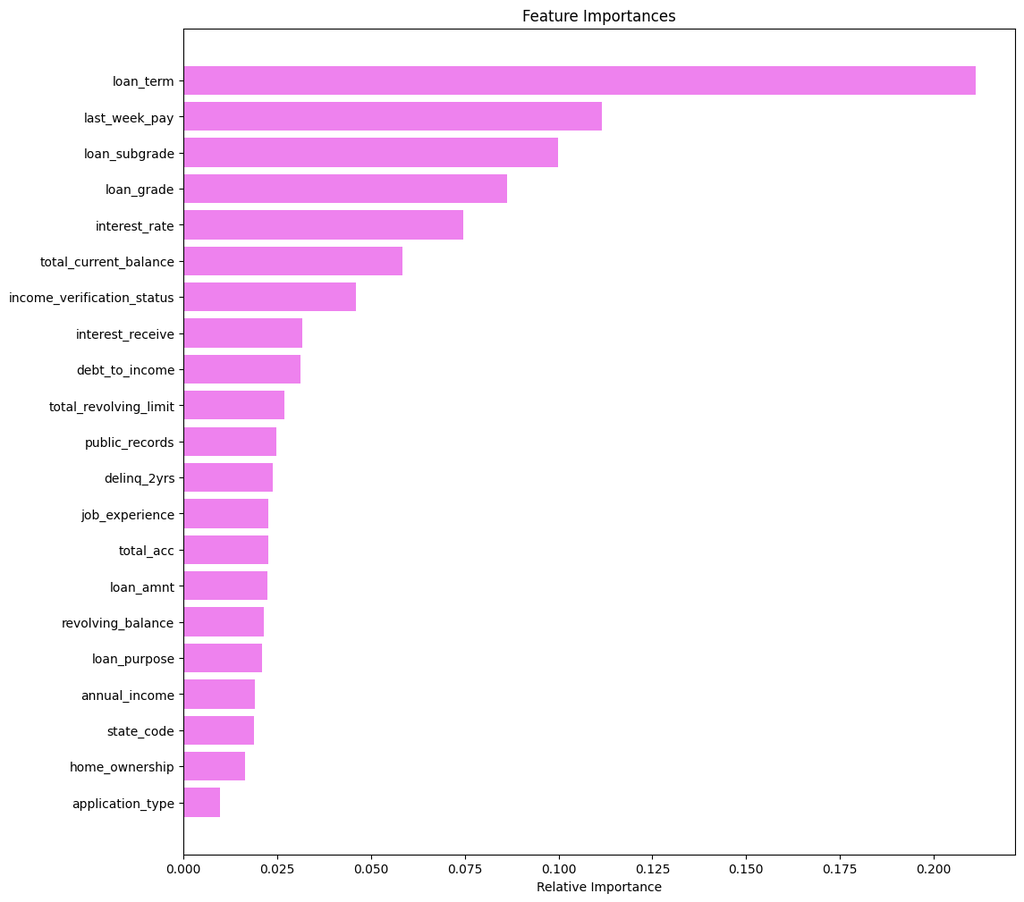

```python
# Extract feature importances from the best model (refit)
best_model = grid_cv.best_estimator_

# Get the feature importances
importances = best_model.feature_importances_

# Assume feature names are the columns of X_train
feature_names = X_train.columns

# Get the indices that would sort the array (ascending)
indices = np.argsort(importances)

# Plot the feature importances
plt.figure(figsize=(12, 12))
plt.title("Feature Importances")
plt.barh(range(len(indices)), importances[indices], color="violet", align="center")
plt.yticks(range(len(indices)), [feature_names[i] for i in indices])
plt.xlabel("Relative Importance")
plt.show()
```

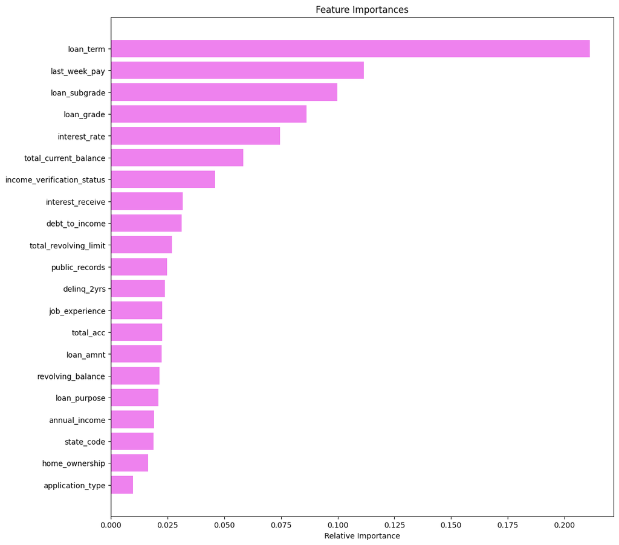

```python
# Extract feature importances from the best model (refit)
best_model = randomized_cv.best_estimator_

# Get the feature importances
importances = best_model.feature_importances_

# Assume feature names are the columns of X_train
feature_names = X_train.columns

# Get the indices that would sort the array (ascending)
indices = np.argsort(importances)

# Plot the feature importances
plt.figure(figsize=(12, 12))
plt.title("Feature Importances")
plt.barh(range(len(indices)), importances[indices], color="violet", align="center")
plt.yticks(range(len(indices)), [feature_names[i] for i in indices])
plt.xlabel("Relative Importance")
plt.show()
```

1.Both the GridSearch and RandomizedSearch give the same relative importance of features in the same descending order from top down. 2.loan_term follow by last_week_pay are most important features while the least is application_type.**Pipelines to Build the Final Model** 1.Now that we have a final model, let's use pipelines to put the model into production. We know that we can use pipelines to standardize the model building, but the steps in a pipeline are applied to each and every variable. 2.We use Column Transformer to personalize the pipeline to perform different preprocessing steps on different column 3.Using pipeline models is a best practice in designing machine learning workflows. They help ensure consistency, reduce errors, and streamline experimentation and deployment processes, making machine learning projects more robust, maintainable, and scalable.s.

```python
# Extract numerical and categorical columns
numerical_cols = X.select_dtypes(include=np.number).columns.tolist()
categorical_cols = X.select_dtypes(include=['object']).columns.tolist()
```

```python
# Define the ColumnTransformer: applies different preprocessing
preprocessor = ColumnTransformer(
    transformers=[
        ('num', StandardScaler(), numerical_cols)
    ], remainder='passthrough'
)
```

```python
# Fit the pipeline with the best model
best_pipeline_model = Pipeline([
    ('preprocessor', preprocessor),
    ('classifier', XGBClassifier(random_state=42, eval_metric='logloss'))
])
```

**fit the pipeline model**

```python
# Fit the pipeline model
best_pipeline_model.fit(X_train, y_train)
```

```
Pipeline(steps=[('preprocessor',
                 ColumnTransformer(remainder='passthrough',
                                   transformers=[('num', StandardScaler(),
                                                  ['loan_amnt', 'loan_term',
                                                   'interest_rate',
                                                   'loan_grade',
                                                   'loan_subgrade',
                                                   'job_experience',
                                                   'home_ownership',
                                                   'annual_income',
                                                   'income_verification_status',
                                                   'loan_purpose', 'state_code',
                                                   'debt_to_income',
                                                   'delinq_2yrs',
                                                   'public_records',
                                                   'revolving_ba...
                               feature_types=None, gamma=None, grow_policy=None,
                               importance_type=None,
                               interaction_constraints=None, learning_rate=None,
                               max_bin=None, max_cat_threshold=None,
                               max_cat_to_onehot=None, max_delta_step=None,
                               max_depth=None, max_leaves=None,
                               min_child_weight=None, missing=nan,
                               monotone_constraints=None, multi_strategy=None,
                               n_estimators=None, n_jobs=None,
                               num_parallel_tree=None, random_state=42, ...))])
```

```python
# Predict on validation data for evaluation
y_val_pred = best_pipeline_model.predict(X_val)
print(y_val_pred)
```

```
[1 0 0 ... 0 0 0]
```

```python
# Evaluate the pipeline on validation data
accuracy =  accuracy_score(y_val, y_val_pred)
print(f'Validation Accuracy: {accuracy * 100:.2f}%')
```

```
Validation Accuracy: 87.15%
```

The pipeline model gives Validation accuracy of 87.15%.

```python
# Predict on test data
test_pred = best_pipeline_model.predict(X_test)
test_pred
```

```
array([1, 0, 1, ..., 0, 0, 0])
```

```python
# Output submission file if 'ID' column exists
if 'ID' in df1.columns:
    submission = pd.DataFrame({'ID': test_data['ID'], 'default': test_pred})
    submission.to_csv('submission.csv', index=False)
```

```python
# Print to confirm the submission file is created successfully
print("Submission file created successfully.")
```

```
Submission file created successfully.
```

**save the result**

```python
# File path
file_path = r'C:\Users\Moses Okesola\submission.csv'

# Read the CSV file
data = pd.read_csv(file_path)

# Display the first few rows of the dataframe
print(data.head(70))
```

```
          ID  default
0    4855329        0
1   66862420        0
2    3637416        0
3   53682249        0
4   53937165        0
..       ...      ...
65  67169666        0
66  31097860        0
67  69594568        0
68  49643881        1
69   1219608        1

[70 rows x 2 columns]
```